# Preparing Marxan Input Files to Optimise for Phylogenetic Diversity

Dan Rosauer

2017-03-24

The conservation planning tool [Marxan](http://marxan.net) is designed to select areas for conservation given distributions of conservation features, costs of conservation and spatial configuration. Conservation planning using phylogenetic diversity (PD) rather than (for example) species as features has been demonstrated in scientific studies, and recently applied using widely used conservtaion planning software such as Marxan.

These scripts aim to make PD-based conservation planning accessible, by combining the spatial and phylogenetic input data, and generating the input files which Marxan requires.

## How it works

If you are not familiar with operation of Marxan, please read this documentation together with the Marxan manual.

Marxan lists the occurrence of each conservation feature (eg a species) in each planning unit in the file puvspr2.dat. And each conservation feature is listed in sp.dat along with a target (the amount to be reserved) and a species protection factor - the relative importance of meeting the target for the feature.

To adapt these input files to work with PD, the tips of a phylogeny are linked to the spatial data, and the input files are augmented in three ways:

1. puvspr2.dat includes, separately, occurrences of each branch on the phylogeny. For internal branches, occurrence is defined as the union of occurences of all decendent tips.
2. sp.dat includes a representation target for every branch on the phylogeny.
3. The species protection factor (spf) for each branch is multiplied by the length of the branch, so the importance of protecting a branch is proportional to its length.

The resulting input files are then run through Marxan as normal.

In the case where multiple phylogenies are used - for example to reflect phylogenetic incertainty - a series of separate directories will be created, each with its own set of input data based on a separate phylogeny.

*This section will eventually have more detail, with a simple tree and map figure.*

## Input Data

Three input files (or equivalent data within your R code) are required:

### Planning Units (PU)

A list of planning units with cost and status, equivalent to pu.dat in Marxan

| PU_ID | cost | status |
| --- | --- | --- |
| 1 | 1 | 0 |
| 2 | 0.324 | 0 |
| 3 | 0.535 | 0 |

The *PU_ID* must be an integer, and cost can be 1 in every case if all PU are treated as of equivalent cost. In this example, *cost* is used as a surrogate for area, and *status* of 0 indicates that the PU is available for selection.

In the example data, this information is drawn from a shapefile.

### Occurrence in planning units

A list of occurrence of *species* or any tree tips in each PU, with an amount, equivalent to puvspr2.dat in Marxan

This data are for species or other tree tips only. Occurrence for intrernal branches is calculated by the scripts.

| TaxonName | PU_ID | Amount |
| --- | --- | --- |
| Antechinomys_laniger | 31635 | 0.34 |
| Petaurus_gracilis | 26967 | 0.36 |
| Macropus_agilis | 26951 | 0.51 |

### Phylogeny

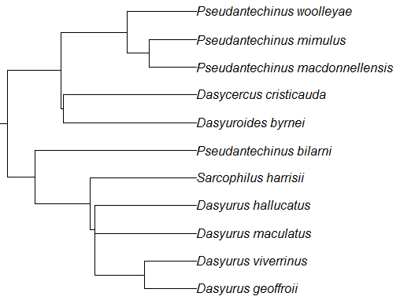

The phylogeny should include tip labels which exactly match the taxon names in the occurrences. This can be achieved in data preparation, or through use of a lookup table in R. Branches with no tips matching the spatial data, will be ignored. Each branch on the tree will become a conservation feature, although short branches will have minimal imact on the result as they will receive a very low Species Protection Factor (SPF).

## The Code

Two files are provided:

- `PD_for_Marxan_example.r` is an example script showing how the PD Marxan functions can be called. It uses sample data, for mammals in Australia.
- `PrepareMarxanInputs.r` contains functions to determine the occurence and range size of each branch, set targets and generate the Marxan files.

## Get Branch Ranges

**Description**

- Match taxon (or other) names in the spatial data to tip labels on the phylogeny and determine the occurrence of each branch.
- Loop through multiple trees if provided.
- Call marxan_inputs which creates the Marxan input files

**Usage**

get_branch_ranges (trees, planningUnits, occ, output_dir, amount_max = 0, spf_multiplier = 1)

[output not shown]

**Details**

The `amount_max` argument is needed because of the way that occurrence amounts sum for internal branches. In some cases it makes sense that the amount of an occurence for an internal branch is the sum of the occurences at the tips, for example if amount represents abundance within a PU. In other cases, such as where amount represents proportion of area occupied within a PU, this area should not be greater than 1. In such cases setting `amount_max` to 1 ensures that the values stay within the correct range.

In a Marxan optimisation, it is often necessary to adjust the species protection factor (SPF) to achieve a balance between meeting conservation targets and other priorities (spatial configuration and minimizing cost). The SPF is used in this case to represent branch length, but any global adjustment to the SPF can be applied as a multiplier on top of the branch length, using the `spf_multiplier`.

This function calls `marxan_inputs()` once for each tree provided. A simpler alternative would have those two functions called independently, but the advantage of this approach is that for a large multi-tree analysis, `extract branch ranges` does not need to hold in memory and return distribution data for all trees at the smae time. Instead, branch distribution data for each tree is generated and written to file before starting the next tree.

**Value** Nothing is returned by this function. The outputs are the files generated to run Marxan.

## Marxan Inputs

**Description**

Generates marxan input files from a single tree and corresponding data on node ranges. `marxan_inputs()` is called from within `extract_branch_ranges`, but can also be called directly.

**Usage**

marxan_inputs (tree, branch_ranges, node_occ, planningUnits, target, spf_multiplier, write.dir)

[output not shown]

**Details**

`target` defines the type of conservation target to be applied to each branch, and written to spec.dat. `target` is interpreted in two ways:

- values between 0 and 1 set the conservation target for each branch as that. proportion of its range.
- values of >= 1 must be integers, and each refers to a target strategy defined in the function `get_target()`. See documentation for `get_target()`.

`marxan_inputs()` prepares the following files for Marxan, as described in the Marxan manual, but with particular characteristics as described here:

[output not shown]

**Value** `marxan_inputs()` does not return any value.

## Get Targets

**Description**

Accepts a vector of range size (or total amount) and a single target option, and returns a vector of target values.

**Usage**

get_target <- (range, option=1)

| Argument | Usage |
| --- | --- |
| `range` | a numeric vecotr of the range size (or total amount) for conservation features, such as a species or branch. |
| `option` | an integer indicating the type of target to be used, from the list given below in *Details*. |

**Details**

The argument `range` can represent an area in any units, or the sum of any valiue used as the amount, such as abundance.

The `option` can be chosen from the set of currently available target setting strategies, which are:

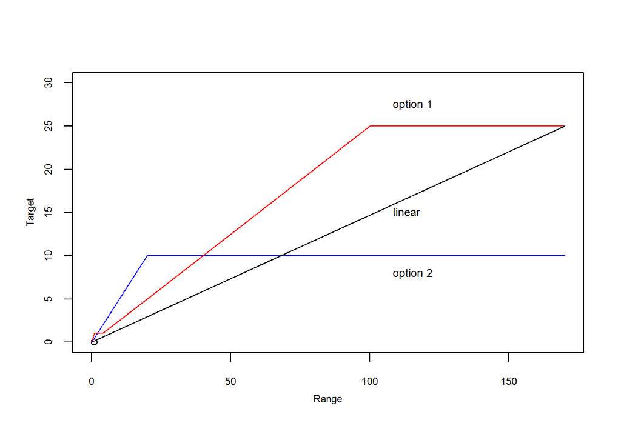

Target v Range size for *bounded percentage* strategies (options 1 and 2) and for a simple percentage of range (linear).

**Value** `get_target()` returns a vector or target amounts.

## Other functions

Other functions are for internal use, such as variable validation, and not documented.

## About the author

Dan Rosauer is a research fellow at Australian National University who studies the phylogenetic component of biological diversity to explain and conserve spatial patterns of evolutionary diversity.

Email: dan.rosauer@anu.edu.au

Website: [sites.google.com/site/danielrosauer](http://sites.google.com/site/danielrosauer/)

Github: github.com/DanRosauer/